# Understanding Drivers of High Sierra Lakes Communities

Ray Hunter

2023-12-03

## Introduction

The Sierra Nevada Mountains of California contain some of the nations most pristine wilderness, including thousands of lakes scattered throughout the range. Historically, the majority of these lakes were not inhabited with fish due to their fragmented and isolated nature, making it very difficult for fish to access lakes at high elevation. The Department of Fish and Wildlife began to stock these lakes in the later 19th century to promote recreational fishing in the range. While this provided many benefits to society, the long term ecological impacts still are not fully understood. These introduced trout (Rainbow, Brooke, Golden, Brown, Cutthroat, and hybrids) rely on zooplankton, a broad classifications of small organisms suspended in the water column that feed on phytoplankton and microbes, as a main food source in their “Fry” stage of life.

This study aims to understand the abiotic (non-living) and biotic (living) factors that influence zooplankton community dynamics in the High Sierra. The questions being asked are:

**1) How does the size and elevation of lakes affect the species diversity and richness of zooplankton?**

**2) Does the presence of fish influence the diversity and richness of zooplankton in these lakes?**

To answer these questions, I modeled the species diversity and richness of zooplankton as a function of these factors using multiple linear regression models. Because previous literature suggests that lakes become more oligotrophic (less nutrient input) with increasing elevation and support smaller foodwebs with decreasing size, I hypothesize that the diversity and richness of zooplankton communities will lessen as elevation increases and size decreases. Furthermore, the presence of fish will present selective predation on certain zooplankton species, altering species diversity and richness as well.

Map Data

- Sierra Nevada Polygon: https://gis.data.cnra.ca.gov/datasets/727b3cc24f8549759fe946a298dc3a20/explore?location=38.508918%2C-118.370394%2C6.43
- Sierra Nevada Wilderness Polygons: https://wilderness.net/visit-wilderness/gis-gps.php
- Base Layer: google maps

```r
#sierra nevada boundary
snb <- read_sf("./data/SNV_boundary/Sierra_Nevada_Conservancy_Boundary.shp")

#wilderness boundaries
wilderness <- read_sf("./data/wilderness/Wilderness_Areas_122721.shp") %>%
  st_transform(crs = st_crs(snb)) %>%
  clean_names() %>%
  select(name, state) %>%
  filter(state == "CA") %>%
  st_filter(y = snb, .predicate = st_within)

snb <- snb %>% st_transform(4326)
wilderness <- wilderness %>% st_transform(4326)
```

[figure not shown]

**Figure 1.** Map of the Sierra Nevada Mountain Range in California.

```r
register_google(key = "AIzaSyAMlAe4fbAxjFToWnpW-28exZtSUC6bXL8")
api_key <- "AIzaSyAMlAe4fbAxjFToWnpW-28exZtSUC6bXL8"
basemap <- get_googlemap(center = c(lon = -119.9, lat = 37.715161),
                         zoom = 7,
                         maptype = "terrain",
                         key = api_key)


map <- ggmap(basemap) +
    geom_sf(data = snb, color = "black",  fill = "lightblue4", alpha = .3, inherit.aes = FALSE) +
  geom_sf(data = wilderness, color = "black", fill = "cyan3", alpha = .3, inherit.aes = FALSE) +
   labs(title = "The Sierra Nevada Mountains", x = "", y = "") +
  theme_classic() +
     annotation_scale(location = "bl",
                      pad_y = unit(0.4, "in")) +
  annotation_north_arrow(location = "bl",
                         pad_x = unit(0.5, "in"),
                         pad_y = unit(0.8, "in"),
                         height = unit(.4, "in"),
                           width = unit(.3, "in"),
                         size = 5)
map
```

```r
ggsave("figures/map.png", map)
```

## Methods

Over 1,100 lakes were surveyed from 1995-2002 as a part of the [Sierra Lakes Inventory Project (SLIP)](https://search.dataone.org/view/https://pasta.lternet.edu/package/metadata/eml/edi/577/2#https://pasta.lternet.edu/package/data/eml/edi/577/2/eae835e83c0494a376229f254f7d3392), with the goal of describing the biodiversity of lentic water bodies in lakes, ponds, marshes, and meadows in the Southern Sierra. All study observation and samples were collected between months of July and September. Area and elevation of the lakes were calculated using GPS and GIS for lakes where area was unknown. Fish presence was measured using both visual and net surveys at the edge of lakes to identify species presence. Zooplankton samples were collected in water samples that were then packed out and identified in the lab at the Sierra Nevada Aquatic Research Laboratory (SNARL) in Mammoth Lakes, California. Due to the varying stages of maturity and small sizes of zooplankton, taxon were sometimes identified to genus, family, or life stage if not able to be identified to species level. Zooplankton samples were originally collected in 3 different subsamples, so diversity was averaged for all 3 lake subsamples to calculate each lake’s Shannon-Wiener diversity index. Species richness was calculated by identifying unique taxon across all 3 samples. Zooplankton data was not collected in 1998, 1999, or 2002.

## Results

```r
############################# reading in data ##################################
# fish sample data
fish <- read.csv("data/Fish.csv") %>%
  clean_names()

#lakes data
lake <- read.csv("data/Lake.csv") %>%
  clean_names() %>%
  #lake id code names
  left_join(data.frame(lake_type_code = c(1,3,4,5,9,10,11,12), lake_code_name = c("perennial", "unmapped pond", "stream widening", "marsh", "part of another lake", "unmapped marsh", "ephemeral", "meadow")))

#survey information
survey <- read.csv("data/Survey.csv")

#zooplankton sample sums
zp_samp_sum <- read.csv("data/ZooplanktonSampleSums.csv")

#zooplankton counts
zp_count <- read.csv("data/ZooplanktonSpeciesCounts.csv") %>%
  clean_names()

#zooplankton species names
zp_name <- read.csv("data/ZooplanktonSpeciesName.csv") %>%
  clean_names()

############################# processing data ##################################

# organizing zoo plankton diversity data frame
zp_mod <- zp_count %>%
  group_by(lake_id, survey_date, subsample) %>%
  summarise(species_id = species_id, number = number, diversity = vegan::diversity(number)) %>%
  group_by(lake_id, survey_date) %>%
  summarise(mean_div = mean(diversity), richness = length(unique(species_id))) %>%
  left_join(lake) %>%
  select(-c(lake_drainage_name, lake_quad_name, lake_county_name, lake_juris_name, lake_wilderness_name))

#fish
fish_mod <- fish %>%
  group_by(lake_id, survey_date, fish_species) %>%
  summarise(mean_length = mean(fish_length), mean_weight = mean(fish_weight)) %>%
  left_join(lake) %>%
  select(-c(lake_drainage_name, lake_quad_name, lake_county_name, lake_juris_name, lake_wilderness_name)) %>%
  mutate(lake_status = ifelse(any(fish_species %in% c("BK", "BN")), "non-native", "native"))

#full join of fish and zp
zp_fish <- left_join(zp_mod, fish_mod)

#fish presence df
fish_actual <- survey %>%
  select(lake_id, actual_fish_presence)

#final join with fish presence
total <- left_join(zp_fish, fish_actual) %>%
  mutate(year = factor(year(mdy(survey_date)), levels = c("1996", "1997", "2000", "2001"))) %>%
mutate(lake_code_name = factor(lake_code_name))
  # mutate(year = as_date(year))
```

### Exploratory Data Analysis

*Note:Log area is used in this study as the area had a skewed distribution, and the log transformation suited the data better for linear modeling.*

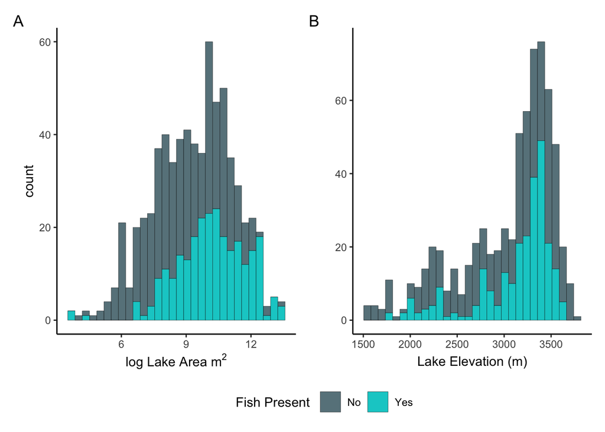

**Figure 2. A)** Histogram showing the frequency of lakes observed by log area. **B)** Histogram showing the frequency of lakes observed by elevation.

```r
h1 <- ggplot(data = total , aes(x = log(lake_area_nbr),  fill = actual_fish_presence)) +
  geom_histogram(color = "black", size = .1) +
  scale_fill_manual(name = "Fish Present ", values = c("lightblue4", "cyan3")) +
  theme_classic() +
  labs(x = expression("log Lake Area m"^2))



h2 <- ggplot(data = total , aes(x = lake_elevation_nbr, fill = actual_fish_presence)) +
  geom_histogram(color = "black", size = .1) +
  scale_fill_manual(name = "Fish Present ", values = c("lightblue4", "cyan3")) +
  theme_classic() +
  labs(x = "Lake Elevation (m)", y = "")


hist <- h1 + h2 +
  plot_layout(guides = "collect",
              heights = 5) +
  plot_annotation(tag_levels = "A") &
  theme(legend.position = "bottom")

hist
```

```r
ggsave("figures/hist.png", hist, height = 5, width = 8, unit = 'in')
```

```r
#correlation of independent variables
ind_cor <- cor(log(total$lake_area_nbr), total$lake_elevation_nbr)
```

One concern in working with this data was *collinearity* between independent variables, which can lead to dramatic changes in the dependent variables (diversity and richness) if it occurred. I examined a simple scatterplot to visually inspect for a possible relationship between log lake area and elevation, both with and without fish present (fig.3). While fish seemed to be more frequent in larger lakes and observations were clustered slightly clustered at high elevation, the data points appeared to be scattered and noisy with little evidence of a significant relationship. The correlation between log lake area and elevation was minimal so I kept both independent variables in consideration through the study (r = 0.03.

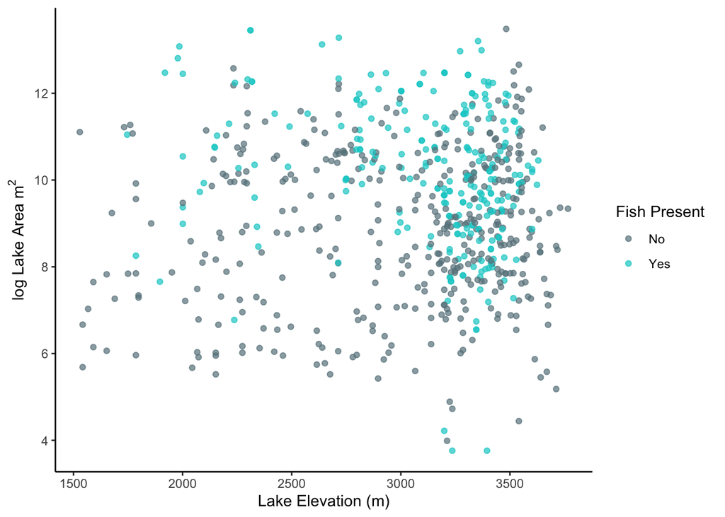

```r
scatter <- ggplot(total, aes(y = log(lake_area_nbr),
                             x = lake_elevation_nbr, color = actual_fish_presence)) +
  geom_point(alpha = .7) +
  scale_color_manual(name = "Fish Present ", values = c("lightblue4", "cyan3")) +
  labs(x = "Lake Elevation (m)", y = expression("log Lake Area m"^2) ) +
  theme_classic()

scatter
```

```r
ggsave("figures/scatter.png", scatter, height = 5, width = 8, unit = 'in')
```

```r
#correlation of independent and dependent variables
cors = total %>%
  group_by(actual_fish_presence) %>%
  summarise(
        cor_da = round(cor(mean_div, log(lake_area_nbr)), 2),
         cor_de = round(cor(mean_div, lake_elevation_nbr), 2),
         cor_ra = round(cor(richness, log(lake_area_nbr)), 2),
         cor_re = round(cor(richness, lake_elevation_nbr), 2))
```

Exploratory data analysis suggested that zooplankton species diversity and richness increases with the log area of a lake and decrease with elevation (fig. 4). The correlation was positive and weaker for species diversity and log lake area when fish were absent compared to present (r = 0.11, r = 0.33) (fig.4.A). Similar results occured for species richness and log lake area (r = 0.05, r = 0.36) (fig.4.B). Diversity and richness in lakes were strongly and negatively correlated with with elevation, and the presence of fish did not change the correlation strength noticeably (r = -0.44, r = -0.45) (fig.4.C). Stronger negative relationships were found between species richness and elevation both with and without fish (r = -0.55, r = -0.53) (fig.4.D).

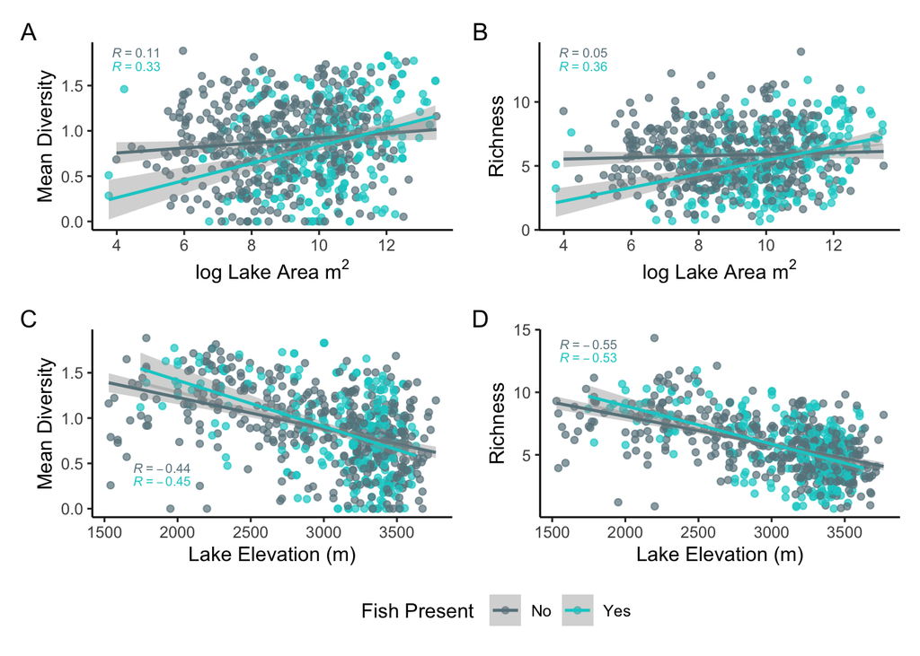

**Figure 4. A)** Mean zooplankton species diversity as a function of lake log area; **B)** Zooplankton species richness as a function of the log area of lakes; **C)** Mean zooplankton species diversity as a function of lake elevation; **D)** Zooplankton species richness as a function of lake elevation; Diversity was calculated using the Shannon-Wiener Index.

```r
# diversity log lake area
da <- ggplot(data = total, aes(x = log(lake_area_nbr), y = mean_div, color = actual_fish_presence)) +
  labs(x = expression("log Lake Area m"^2), y = "Mean Diversity") +
  geom_jitter(alpha = 0.7) +
  geom_smooth(formula = y ~ x, method = "lm", se = T, lwd = 0.8) +
  theme_classic() +
  scale_color_manual(name = "Fish Present ", values = c("lightblue4", "cyan3")) +
  stat_cor(aes(label = ..r.label..),
           r.accuracy = 0.01,
           label.x.npc = .01,
            label.y.npc = 1,
           show.legend = FALSE,
           size = 2.5)

# diversity log lake elevation
de <- ggplot(data = total, aes(x = lake_elevation_nbr, y = mean_div, color = actual_fish_presence)) +
  labs(x = "Lake Elevation (m)", y = "Mean Diversity") +
  geom_jitter(alpha = 0.7) +
  geom_smooth(formula = y ~ x, method = "lm", se = T, lwd = 0.8) +
  theme_classic() +
  scale_color_manual(name = "Fish Present ", values = c("lightblue4", "cyan3")) +
  stat_cor(aes(label = ..r.label..),
           r.accuracy = 0.01,
           label.x.npc = .075,
            label.y.npc = .25,
           show.legend = FALSE,
           size = 2.5)

# richness log lake area
ra<- ggplot(data = total, aes(x = log(lake_area_nbr), y = richness, color = actual_fish_presence)) +
  labs(x = expression("log Lake Area m"^2), y = "Richness") +
  geom_jitter(alpha = 0.7) +
  geom_smooth(formula = y ~ x, method = "lm", se = T, lwd = 0.8) +
  theme_classic() +
  scale_color_manual(name = "Fish Present ", values = c("lightblue4", "cyan3")) +
  stat_cor(aes(label = ..r.label..),
           r.accuracy = 0.01,
           label.x.npc = .01,
            label.y.npc = 1,
           show.legend = FALSE,
           size = 2.5)

# diversity log lake elevation
re <- ggplot(data = total, aes(x = lake_elevation_nbr, y =richness, color = actual_fish_presence)) +
  labs(x = "Lake Elevation (m)", y = "Richness") +
  geom_jitter(alpha = 0.7) +
  geom_smooth(formula = y ~ x, method = "lm", se = T, lwd = 0.8) +
  theme_classic() +
  scale_color_manual(name = "Fish Present ", values = c("lightblue4", "cyan3")) +
  stat_cor(aes(label = ..r.label..),
           r.accuracy = 0.01,
           label.x.npc = .01,
            label.y.npc = 1,
           show.legend = FALSE,
           size = 2.5)

correlations <- (da + ra)/(de + re) +
  plot_layout(guides = "collect",
              heights = 5) +
  plot_annotation(tag_levels = "A") &
  theme(legend.position = "bottom")
# & ylab(NULL) & theme(plot.margin = margin(6.5, 5.5, 0, 5.5))

correlations
```

```r
ggsave("figures/correlations.png", correlations, height = 5, width = 6, unit = 'in')
```

### Multiple Linear Regression

$$diversity_i=\beta_{0}+\beta_{1} \cdot
log(area)_i + \beta_{2} \cdot elevation_i + \beta_{3} \cdot fish_i +
\beta_{4} \cdot log(area)_i \cdot fish_i + \beta_{5} \cdot year_i +
\varepsilon_i$$

$$richness_i=\beta_{0}+\beta_{1} \cdot
log(area)_i + \beta_{2} \cdot elevation_i + \beta_{3} \cdot fish_i +
\beta_{4} \cdot log(area)_i \cdot fish_i + \beta_{5} \cdot year_i +
\varepsilon_i$$

The species diversity model results conclude that the log area (positively) and lake elevation (negatively) significantly affected zooplankton species diversity (p < .05, p < .001). While lakes with fish present reduced zooplankton diversity, no significance was found (P > .05). Similarly, the interaction between log lake area and fish presence was insignificant but positively affected diversity (more so than lakes without fish) (p = .14). No individual year had a significant effect on species diversity.

The species richness model also showed that the log lake area (positively) and lake elevation (negatively) significantly affected zooplankton richness (p < .05, p < .001). Unlike the diversity model, species richness was significantly and negatively affected by the presence of fish in lakes (p < 0.05). The interaction between log lake area and fish presence also was a significant factor in affecting species richness, indicating that the size of the lake affected zooplankton richness differently depending on whether fish were present or not (p < .05). No individual year had a significant effect on species richness.

```r
#diversity model
m_div <- lm(mean_div ~ log(lake_area_nbr) + lake_elevation_nbr + actual_fish_presence + log(lake_area_nbr):actual_fish_presence + year, data = total)
# m_div_sum <- summary(m_div)


#richness model
m_rich <- lm(richness ~ log(lake_area_nbr) + lake_elevation_nbr + actual_fish_presence + log(lake_area_nbr):actual_fish_presence +  year, data = total)
# summary(m_rich)



#creatign a table
tab_model(m_div, m_rich,
          pred.labels = c("Intercept", "log Area", "Elevation",
                          "Fish Presence(Yes)", "1997",
                          "2000", "2001",
                          "log Area x Fish Presence(Yes)"),
          dv.labels = c("Divsersity", "Richness"),
          string.ci = "Conf. Int (95%)",
          string.p = "p-value",
          title = "Table 1. Multiple Linear Regression Model Results.",
          digits = 4)
```

Table 1. Multiple Linear Regression Model Results.

|  | Divsersity |  |  | Richness |  |  |
| --- | --- | --- | --- | --- | --- | --- |
| Predictors | Estimates | Conf. Int (95%) | p-value | Estimates | Conf. Int (95%) | p-value |
| Intercept | 1.8560 | 1.4600 – 2.2521 | **<0.001** | 12.6131 | 10.7139 – 14.5123 | **<0.001** |
| log Area | 0.0285 | 0.0046 – 0.0523 | **0.019** | 0.1383 | 0.0238 – 0.2527 | **0.018** |
| Elevation | -0.0004 | -0.0005 – -0.0003 | **<0.001** | -0.0026 | -0.0031 – -0.0021 | **<0.001** |
| Fish Presence(Yes) | -0.3205 | -0.7335 – 0.0924 | 0.128 | -2.2044 | -4.1847 – -0.2242 | **0.029** |
| 1997 | 0.0830 | -0.0317 – 0.1976 | 0.156 | -0.0721 | -0.6218 – 0.4777 | 0.797 |
| 2000 | -0.0304 | -0.1515 – 0.0906 | 0.621 | -0.3699 | -0.9504 – 0.2106 | 0.211 |
| 2001 | 0.0192 | -0.1260 – 0.1644 | 0.795 | -0.1259 | -0.8223 – 0.5706 | 0.723 |
| log Area x Fish Presence(Yes) | 0.0305 | -0.0100 – 0.0710 | 0.140 | 0.2185 | 0.0242 – 0.4129 | **0.028** |
| Observations | 545 |  |  | 545 |  |  |
| R<sup>2</sup> / R<sup>2</sup> adjusted | 0.240 / 0.230 |  |  | 0.349 / 0.340 |  |  |

### Residuals

QQ plots were made to test if the residuals were normally distributed (fig.5). As seen in the plots, the residuals for both models fit the normal distribution quite well, with the exception of a slight and minor deviation in the tails. This implies that the diversity model residuals have a slight negative skew (fig.5.A), and the richness model has slightly fatter than expected tails (fig.5.B). In conclusion, the QQ plots imply assumptions of normality are met.

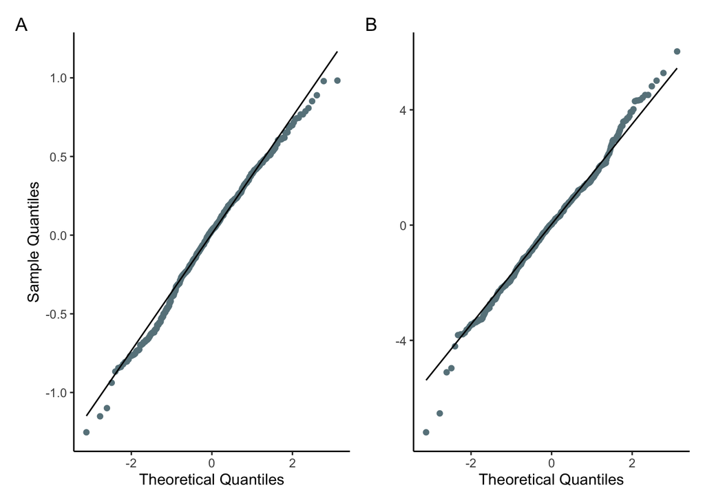

**Figure 5. A)** QQ plot of zooplankton species diversity model residuals. Theororetical and sample residuals are generally suggestive of a normal distribution, but show slight deviation in the tails which suggest the distribution has a slight negative skew. **B)** QQ plot of zooplankton species richness model residuals. Theororetical and sample residuals are generally suggestive of a normal distribution, but show slight deviation in the tails which suggest the distribution has fat tails.

```r
#diversity model residuals
m_div_res <- residuals(m_div)
#richness model residuals
m_rich_res <- residuals(m_rich)


#qq plot for diversity
div_qq <-  ggplot( m_div, aes(sample = .resid)) +
  geom_qq(color = "lightblue4") +
  geom_qq_line() +
  theme_classic() +
  labs( x = "Theoretical Quantiles", y = "Sample Quantiles")

#qq plot for richness
rich_qq <-  ggplot( m_rich, aes(sample = .resid)) +
  geom_qq(color = "lightblue4") +
  geom_qq_line() +
  theme_classic() +
  labs( x = "Theoretical Quantiles", y = "")

#joining plots
qq <- div_qq + rich_qq +
plot_annotation(tag_levels = "A")

qq
```

```r
ggsave("figures/residuals.png", qq, height = 5, width = 8, unit = 'in')
```

## Discussion

Zooplankton species diversity and richness are closely related, and they both responded similarly to abiotic conditions (log lake area and lake elevation). However, species richness was noticeably lower in lakes with fish present compared to without when holding lake area and elevation constant, indicating that biotic factors (fish present) alter the ability of specific zooplankton species to persist (likely due to taxa specific predation).

The most interesting result from these findings is, however, that the area of a lake affects the zooplankton species richness noticeably more when fish are present as seen in the interaction coefficient of the richness model. Richness is very low in small lakes and very high in large lakes when fish are present (steep positive slope), whereas richness is moderate to high in lakes without fish (moderate positive slope). This begs the question: **Why are zooplankton more sensitive to changes in lake area when fish are present vs absent?** This question can be answered by the ecological principle known as the *Island Biogeography Theory* which states that prey on smaller islands (or habitats) experience more intense predation pressure from predators than on larger islands. Due to their isolation and limited resources, zoo plankton in small lakes experience higher extinction rates from concetrated predation, less resources (nutrient input), and lower emigration. This applies quite literally into our study system here were introduced fish in small lakes (islands) suppress zooplankton species richness (prey) more intensely than in larger lakes (islands).

This study did not include a spatial element as coordinates were not provided in the data as a measure to keep sensitive and rare fish lakes discreet. Future research should look at other taxa in oligotrophic alpine lake food webs (algae, microbes, benthic macroinvertebrates) to understand potential trophic cascades and community wide effects of fish introduction.